# Finding a good author and then read his mind

Exploratory data analysis for the Hacker News forum

Hendrik A. Dreyer

8 May 2019

[figure not shown]

# Introduction

Hacker News is a social news website focusing on computer science and entrepreneurship. It is run by Paul Graham’s investment fund and startup incubator, Y Combinator. In general, content that can be submitted is defined as “anything that gratifies one’s intellectual curiosity”

We’ll need the following R libraries for this EDA:

```r
library(dplyr)
library(readr)
library(ggplot2)
library(httr)
library(data.table)
library(lubridate)
library(bigrquery)
```

YCombinator.com has released the contents of its online forum to Google. The forum content is freely available as a public BigQuery dataset as [bigquery-public-data.hacker_news.](https://console.cloud.google.com/bigquery?p=bigquery-public-data&d=hacker_news). There are 4 tables listed under the hacker_news entry:

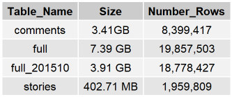

This EDA utilises primarily the stories and comments table. The stories table holds all the stories published on the forum along with a score that is assigned to it based on the number of up votes it received from forum members. The comment table holds all of the comments that forum users posted in regards to the posts in the stories table.

Interrogate Google BigQuery to find out who are the authors with the higest scores.

```r
# Example query - select copies of files with content containing "TODO"
sql <- "SELECT
          sum(score) as high_scores, author
        FROM
          [bigquery-public-data.hacker_news.stories]
        GROUP BY
          author
        ORDER BY
          high_scores DESC
        LIMIT 10"

# Execute the query and store the result
todo_copies <- query_exec(sql, project = project)
```

Plot the results.

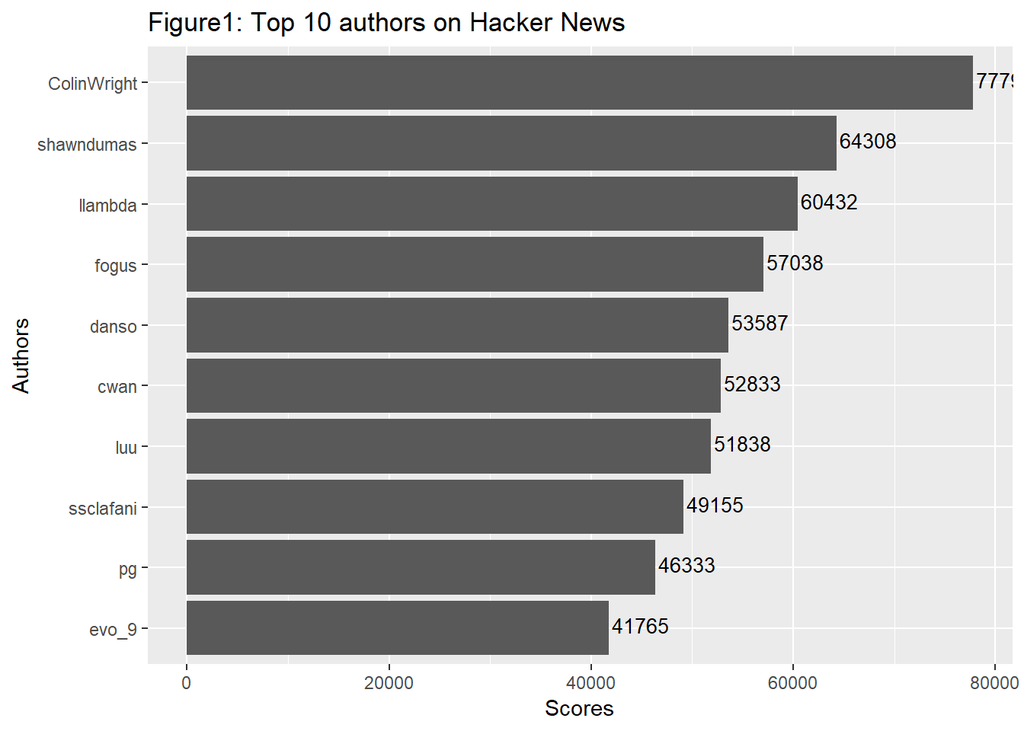

```r
ggplot(data = todo_copies, aes(x = reorder(author, high_scores), y = high_scores)) +
  geom_bar(stat="identity") +
  labs(x = "Authors", y = "Scores") +
  ggtitle("Figure1: Top 10 authors on Hacker News") +
  coord_flip() +
  geom_text(aes(label=high_scores), vjust=0.3, hjust=-0.05, size=3.5)
```

We can see that ColinWright is the clear leader in terms of accumulated scores on all his stories that he wrote. Let’s take a look at how active he was during his years as prolific online forum writer.

```r
sql <- "SELECT YEAR(time_ts) as year_written
        FROM [bigquery-public-data.hacker_news.stories]
        WHERE author = 'ColinWright'
        ORDER BY year_written ASC"

# Execute the query and store the result
todo_copies <- query_exec(sql, project = project)
```

Let’s plot the frequency distribution of Colin’s post

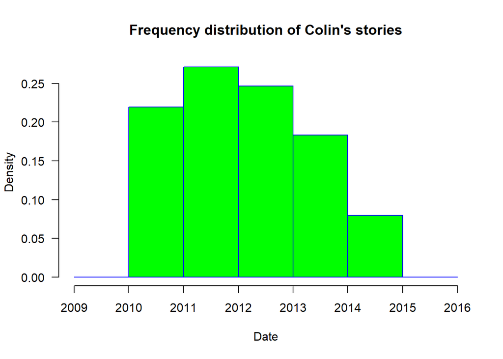

```r
hist(todo_copies$year_written,
     main="Frequency distribution of Colin's stories",
     xlab="Date",
     border="blue",
     col="green",
     xlim=c(2009,2016),
     breaks=c(2009, 2010, 2011, 2012, 2013, 2014, 2015, 2016),
     las=1,
     prob = TRUE)
```

From the above histogram we can observe that Colin bursted onto the HN scene in 2010 and reached his peak in 2011. From 2012 his story posting frequency started dropping off until 2015 where he seemed to have said all he wanted to.

This is impressive, not to say the least. But, another questions comes to mind - “Which metrics do we use to measure the quality of a writer in HN?” Is it the sheer number of points that a writer has racked up? Is it the number of stories that he/she wrote? Is it the frequency with which a writer posts. Or, maybe how large his/her following is? Surely, in my mind, it should be a number of these metrics through which we can determine the quality of a writer’s posts.

Let’s retrieve the count of stories by each author and list them by a quality factor. The quality factor is determined as follows:

QF = Number_of_Points / Number_of_Stories

This will give us effectively the average number of points scored per story posted. Take note: The scoring system on HN is a complex system and as such implicitly includes the size of the author’s following.

```
##             author number_of_stories total_score quality_factor
## 1      realfuncode                 1        1543         1543.0
## 2       frederfred                 2        2905         1452.5
## 3   themanthatfell                 1        1344         1344.0
## 4            rcina                 1        1282         1282.0
## 5           kvargs                 1        1257         1257.0
## 6          mmebane                 1        1248         1248.0
## 7  FlemishBeeCycle                 1        1227         1227.0
## 8       hannahmitt                 1        1172         1172.0
## 9    afraidofadria                 1        1125         1125.0
## 10    patricktomas                 4        4354         1088.5
```

From the above listed table we can see that the author named, “realfuncode” managed to score 1543 points for only 1 post. I have to read that post! The list above is a bit dissatisfying because, as impressed as I am with an author that gets that many points for a single post, I would rather look at authors who have a larger corpus of work. So, instead I’m looking for not only quality (as judged by the peers on HN) but, also quantity. I don’t think Shakespeare would have become the literay giant he is today if he only published “The Tempest”. I hate Caliban, his a tool. So, how do we determine the optimal quality factor that would embody our mistery author of both quality and quantity?  
Let’s do a scatterplot of the total scores against the number of stories for all the authors. Maybe we can gain some insight from visual groupings - (my mouth is watering, I’m thinking clustering…)

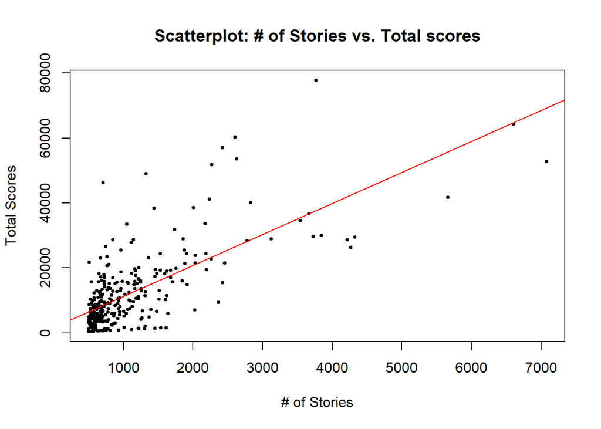

```r
plot(todo_copies$number_of_stories, todo_copies$total_score, main="Scatterplot: # of Stories vs. Total scores",
   xlab="# of Stories", ylab="Total Scores", pch=19, cex=.5)

abline(lm(todo_copies$total_score~todo_copies$number_of_stories), col="red") # regression line (y~x)
```

From the above scatterplot we can see a clear linear relationship between the number of stories posted vs. the accumulated total score raked up for all the stories posted. This was to be expected - more stories, more opportunities to rack up points.  
We can now go ahead and with a certain level of confidence mark an area on the scatterplot which we think defines good quality stories, as follows:

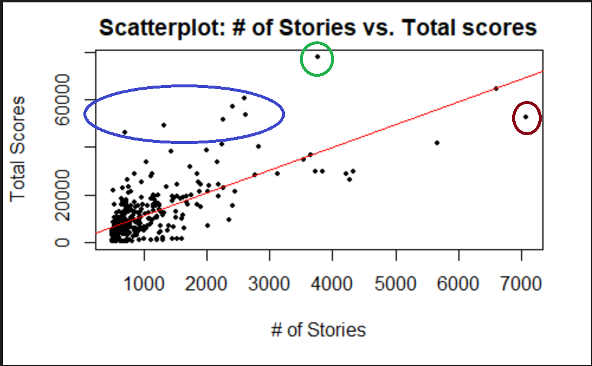

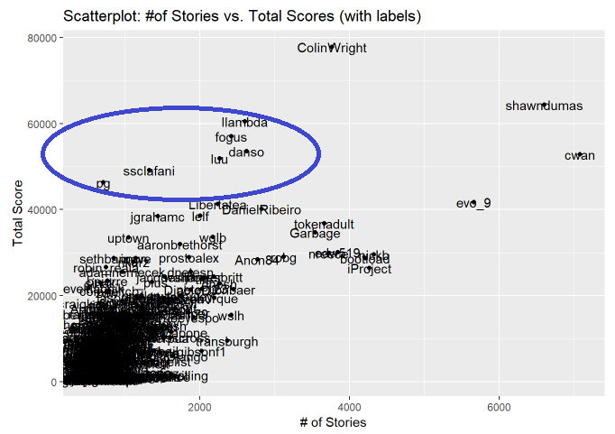

### Figuring out what our chosen candidate writes about

Our quality author, llambda, has written an amazing 2601 posts. We can all agree that is just too many posts to sit down and read in order to get an idea of what llambda is writing about. Fortunately, there are a number of ways to probe the literary content of llambda and that would reveal insight into the mind of llambda. But that is an exercise for another post.